# Exploring NYPD activity from 2009 - 2016

Natasha Mathur

Stop and Frisk is a NYPD policy that was mainly started under Police Commissioner William Bratton. It is associated with the “broken windows” theory - that cracking down on small crimes will help prevent more serious ones - and allows police officers to stop, question, and search people without a warrant or suspicion of a crime.

The number of stops peaked in 2011, along with public outrage about the practice. The policy was heavily criticized for the high amount of force used, the lack of evidence that it improved safety, and most importantly, the fact that most of the people stopped were black or hispanic. Neither the Mayor or Police Commissioner provided an adequate explanation for any of those issues.

In May 2010 officer Adrian Schoolcraft sent the Village Voice recordings that documented orders he had received to stop, frisk, and arrest black people specifically in the Bedford-Stuyvesant neighborhood. This was concrete evidence of both the goals behind the policy and how it was carried out. Two years later protestors silently marched from lower Harlem to then-Mayor Bloomberg’s house on the Upper East Side, demanding that Stop-and-Frisk be ended. That August the practice was deemed unconstitutional.

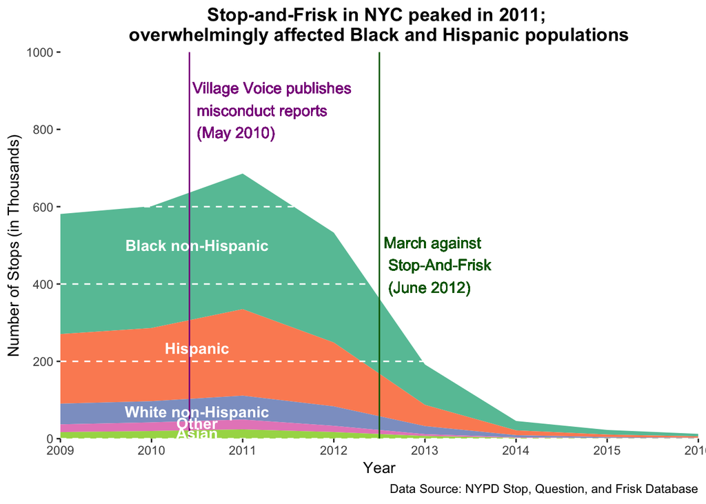

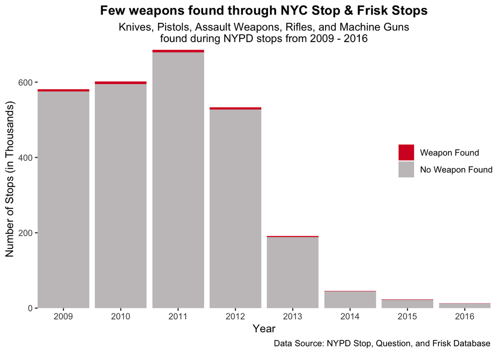

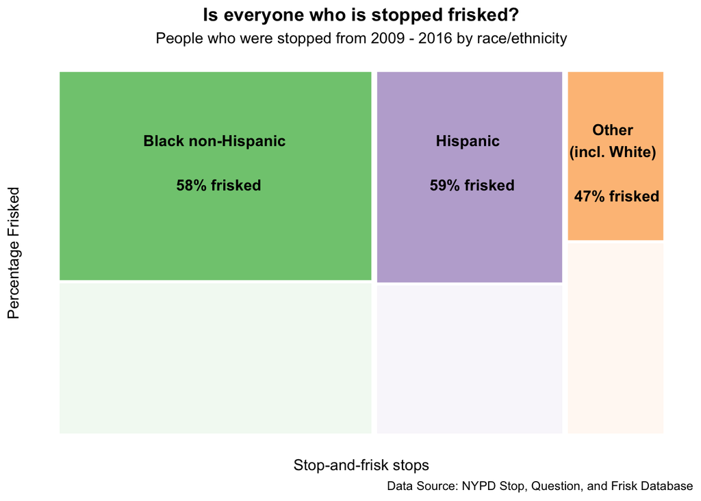

As in any major city, crimes take place in NYC at almost all times of day or night. When a crime is reported the exact time, date, and location of the occurence is noted, along with other information. More crimes happen between about 3pm to 7pm in the evening, and around noon. The number of crimes is also higher in the springtime, from March to June, that at other times of the year.

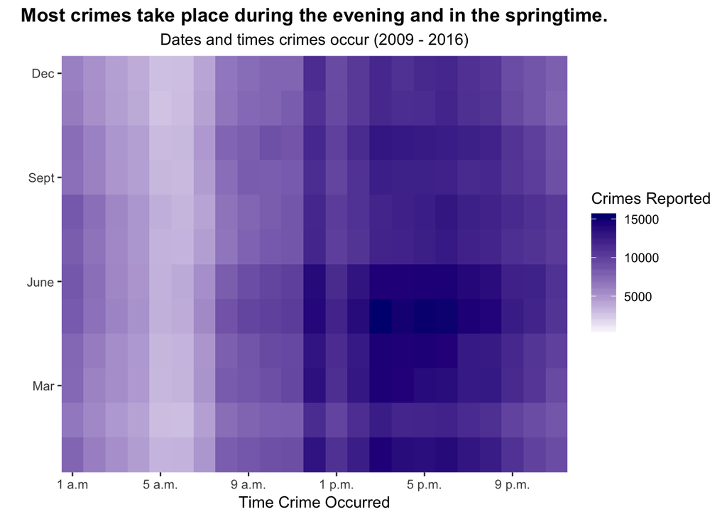

The next topic I was interested in was which crimes were the most common in NYC. A question that quickly came up was how to measure that - by the number of complaints or the number of actual arrests. This discrepancy varies greatly from crime to crime. Charges of “harassment 2” make up almost 15% of reported crimes to the NYPD but there are very few arrests for that offense. In contrast “dangerous drugs” account for about 5% of complaints called in but 18% of arrests.

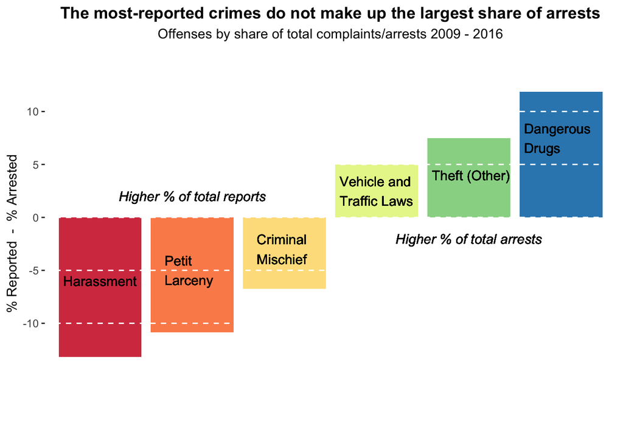